# MSDS 6306: Doing Data Science – Preparing Data

Olga Tanyuk

March 9, 2018

## Harry Potter Cast (50%)

#### a. In the IMDB, there are listings of full cast members for movies. Navigate to http://www.imdb.com/title/tt1201607/fullcredits?ref_=tt_ql_1. Feel free to View Source to get a good idea of what the page looks like in code.

#### b. Scrape the page with any R package that makes things easy for you. Of particular interest is the table of the Cast in order of crediting. Please scrape this table (you might have to fish it out of several of the tables from the page) and make it a data.frame() of the Cast in your R environment

```r
library(XML)
library(rvest)
url <- "http://www.imdb.com/title/tt1201607/fullcredits?ref_=tt_ql_1"
Garry <- read_html(url)
Garry
```

```
## {xml_document}
## <html xmlns:og="http://ogp.me/ns#" xmlns:fb="http://www.facebook.com/2008/fbml">
## [1] <head>\n<meta http-equiv="Content-Type" content="text/html; charset= ...
## [2] <body id="styleguide-v2" class="fixed">\n            <img height="1" ...
```

```r
Garry %>%
html_nodes(css = "table")
```

```
## {xml_nodeset (31)}
##  [1] <table class="simpleTable simpleCreditsTable">\n<colgroup>\n<col cl ...
##  [2] <table class="simpleTable simpleCreditsTable">\n<colgroup>\n<col cl ...
##  [3] <table class="cast_list">\n<tr><td colspan="4" class="castlist_labe ...
##  [4] <table class="simpleTable simpleCreditsTable">\n<colgroup>\n<col cl ...
##  [5] <table class="simpleTable simpleCreditsTable">\n<colgroup>\n<col cl ...
##  [6] <table class="simpleTable simpleCreditsTable">\n<colgroup>\n<col cl ...
##  [7] <table class="simpleTable simpleCreditsTable">\n<colgroup>\n<col cl ...
##  [8] <table class="simpleTable simpleCreditsTable">\n<colgroup>\n<col cl ...
##  [9] <table class="simpleTable simpleCreditsTable">\n<colgroup>\n<col cl ...
## [10] <table class="simpleTable simpleCreditsTable">\n<colgroup>\n<col cl ...
## [11] <table class="simpleTable simpleCreditsTable">\n<colgroup>\n<col cl ...
## [12] <table class="simpleTable simpleCreditsTable">\n<colgroup>\n<col cl ...
## [13] <table class="simpleTable simpleCreditsTable">\n<colgroup>\n<col cl ...
## [14] <table class="simpleTable simpleCreditsTable">\n<colgroup>\n<col cl ...
## [15] <table class="simpleTable simpleCreditsTable">\n<colgroup>\n<col cl ...
## [16] <table class="simpleTable simpleCreditsTable">\n<colgroup>\n<col cl ...
## [17] <table class="simpleTable simpleCreditsTable">\n<colgroup>\n<col cl ...
## [18] <table class="simpleTable simpleCreditsTable">\n<colgroup>\n<col cl ...
## [19] <table class="simpleTable simpleCreditsTable">\n<colgroup>\n<col cl ...
## [20] <table class="simpleTable simpleCreditsTable">\n<colgroup>\n<col cl ...
## ...
```

```r
table_cast = (Garry %>% html_nodes(css = "table"))[[3]] %>%
html_table()
Cast <- data.frame(table_cast)
head(Cast)
```

```
##   X1               X2  X3                         X4
## 1
## 2       Ralph Fiennes ...             Lord Voldemort
## 3      Michael Gambon ... Professor Albus Dumbledore
## 4        Alan Rickman ...    Professor Severus Snape
## 5    Daniel Radcliffe ...               Harry Potter
## 6        Rupert Grint ...                Ron Weasley
```

#### c. Clean up the table

• It should not have blank observations or rows, a row that should be column names, or just ‘…’

• It should have intuitive column names (ideally 2 to start – Actor and Character)

```r
Cast_1 <- Cast[-1,c(-1, -3)]
names(Cast_1) <- c("Actor", "Character")
head(Cast_1)
```

```
##              Actor                  Character
## 2    Ralph Fiennes             Lord Voldemort
## 3   Michael Gambon Professor Albus Dumbledore
## 4     Alan Rickman    Professor Severus Snape
## 5 Daniel Radcliffe               Harry Potter
## 6     Rupert Grint                Ron Weasley
## 7      Emma Watson           Hermione Granger
```

• In the film, Mr. Warwick plays two characters, which makes his row look a little weird. Please replace his character column with just “Griphook / Professor Filius Flitwick” to make it look better.

```r
#Lets find the line with Mr. Warwick
grep("Warwick", Cast_1$Actor)
```

```
## [1] 10
```

We found that line 10 contains name Mr. Warwick.

```r
print(Cast_1[10,])
```

```
##            Actor                                           Character
## 11 Warwick Davis Griphook /  \n            Professor Filius Flitwick
```

```r
Cast_1[10,] <- c("Warwick Davis", "Griphook / Professor Filius Flitwick")
print(Cast_1[10,])
```

```
##            Actor                            Character
## 11 Warwick Davis Griphook / Professor Filius Flitwick
```

• One row might result in “Rest of cast listed alphabetically” – remove this observation.

```r
#Lets find the line with “Rest of cast listed alphabetically”
grep("Rest of cast listed alphabetically", Cast_1)
```

```
## [1] 1 2
```

```r
#We found that we have these words in both colums, lets check which line and delete it
grep("Rest of cast listed alphabetically", Cast_1$Actor)
```

```
## [1] 92
```

```r
Cast_2 <- Cast_1[-92,]
#Lets check that we do not have these words anywhere
grep("Rest of cast listed alphabetically", Cast_2$Actor)
```

```
## integer(0)
```

```r
grep("Rest of cast listed alphabetically", Cast_2$Character)
```

```
## integer(0)
```

#### d. Split the Actor’s name into two columns: FirstName and Surname. Keep in mind that some actors/actresses have middle names as well. Please make sure that the middle names are in the FirstName column, in addition to the first name (example: given the Actor Frank Jeffrey Stevenson, the FirstName column would say “Frank Jeffrey.”)

#### e. Present the first 10 rows of the data.frame() – It should have only FirstName, Surname, and Character columns.

```r
library(tidyr)
Cast_3 <- extract(Cast_2, Actor, c("FirstName", "Surname"), "([^ ].+) (.*)")
head(Cast_3,20)
```

```
##        FirstName   Surname                            Character
## 2          Ralph   Fiennes                       Lord Voldemort
## 3        Michael    Gambon           Professor Albus Dumbledore
## 4           Alan   Rickman              Professor Severus Snape
## 5         Daniel Radcliffe                         Harry Potter
## 6         Rupert     Grint                          Ron Weasley
## 7           Emma    Watson                     Hermione Granger
## 8         Evanna     Lynch                        Luna Lovegood
## 9       Domhnall   Gleeson                         Bill Weasley
## 10      Clémence     Poésy                       Fleur Delacour
## 11       Warwick     Davis Griphook / Professor Filius Flitwick
## 12          John      Hurt                           Ollivander
## 13 Helena Bonham    Carter                  Bellatrix Lestrange
## 14        Graham      Duff                          Death Eater
## 15       Anthony   Allgood                     Gringotts' Guard
## 16         Rusty     Goffe               Aged Gringotts' Goblin
## 17           Jon       Key                               Bogrod
## 18         Kelly Macdonald                     Helena Ravenclaw
## 19         Jason    Isaacs                        Lucius Malfoy
## 20         Helen   McCrory                      Narcissa Malfoy
## 21           Tom    Felton                         Draco Malfoy
```

## 2. SportsBall (50%)

#### a. On the ESPN website, there are statistics of each NBA player. Navigate to the San Antonio Spurs current statistics (likely http://www.espn.com/nba/team/stats/_/name/sa/san-antonio-spurs). You are interested in the Shooting Statistics table.

#### b. Scrape the page with any R package that makes things easy for you. There are a few tables on the page, so make sure you are targeting specifically the Shooting Statistics table.

```r
url <- "http://www.espn.com/nba/team/stats/_/name/sa/san-antonio-spurs"
San_Antonio_Spurs <- read_html(url)
San_Antonio_Spurs
```

```
## {xml_document}
## <html xmlns:fb="http://www.facebook.com/2008/fbml">
## [1] <head>\n<meta http-equiv="Content-Type" content="text/html; charset= ...
## [2] <body class="nba {sportId:46, teamId:24} clubhouse sa" data-sport="n ...
```

```r
San_Antonio_Spurs %>%
html_nodes(css = "table")
```

```
## {xml_nodeset (2)}
## [1] <table cellspacing="1" cellpadding="3" class="tablehead">\n<tr class ...
## [2] <table cellspacing="1" cellpadding="3" class="tablehead">\n<tr class ...
```

```r
table_Shooting = (San_Antonio_Spurs %>% html_nodes(css = "table"))[[2]] %>%
html_table()
```

#### c. Clean up the table (You might get some warnings if you’re working with tibbles)

• You’ll want to create an R data.frame() with one observation for each player. Make sure that you do not accidentally include blank rows, a row of column names, or the Totals row in the table as observations.

```r
Shooting <- data.frame(table_Shooting)
head(Shooting)
```

```
##                      X1                  X2                  X3
## 1   SHOOTING STATISTICS SHOOTING STATISTICS SHOOTING STATISTICS
## 2                PLAYER                 FGM                 FGA
## 3 LaMarcus Aldridge, PF                 8.7                17.5
## 4     Kawhi Leonard, SF                 5.8                12.3
## 5          Rudy Gay, SF                 4.3                 9.1
## 6          Pau Gasol, C                 3.9                 8.6
##                    X4                  X5                  X6
## 1 SHOOTING STATISTICS SHOOTING STATISTICS SHOOTING STATISTICS
## 2                 FG%                 3PM                 3PA
## 3                .498                 0.4                 1.3
## 4                .468                 1.2                 3.9
## 5                .473                 0.7                 2.0
## 6                .459                 0.7                 1.7
##                    X7                  X8                  X9
```

[output cut: 20 more lines]

```r
#Lets rename headers and after that delete 1st, 2nd and the last lines
names(Shooting) <- Shooting[2,]
Shooting <- Shooting[c(-1,-2,-20),]
head(Shooting)
```

```
##                  PLAYER FGM  FGA  FG% 3PM 3PA  3P% FTM FTA  FT% 2PM  2PA
## 3 LaMarcus Aldridge, PF 8.7 17.5 .498 0.4 1.3 .313 4.4 5.2 0.83 8.3 16.2
## 4     Kawhi Leonard, SF 5.8 12.3 .468 1.2 3.9 .314 3.4 4.2 0.82 4.6  8.4
## 5          Rudy Gay, SF 4.3  9.1 .473 0.7 2.0 .325 2.0 2.6 0.78 3.6  7.1
## 6          Pau Gasol, C 3.9  8.6 .459 0.7 1.7 .387 2.1 2.8 0.76 3.2  6.9
## 7       Patty Mills, PG 3.3  8.0 .417 1.8 4.8 .381 1.2 1.3 0.88 1.5  3.2
## 8     Manu Ginobili, SG 3.2  7.3 .439 1.0 3.1 .327 1.5 1.8 0.86 2.2  4.2
##    2P%   PPS AFG%
## 3 .513 1.268 0.51
## 4 .539 1.315 0.52
## 5 .515 1.241 0.51
## 6 .477 1.243 0.50
## 7 .473 1.211 0.53
## 8 .518 1.225 0.51
```

• The column PLAYER has two variables of interest in it: the player’s name and their position, denoted by 1-2 letters after their name. Split the cells into two columns, one with Name and the other Position.

```r
Shooting_1 <- extract(Shooting, PLAYER, c("Name", "Position"), "([^ ].+) (.*)")
# And lets get rid of "," in the 1st column
Shooting_1$Name <- gsub('.{,}$', '', Shooting_1$Name)
head(Shooting_1)
```

```
##                Name Position FGM  FGA  FG% 3PM 3PA  3P% FTM FTA  FT% 2PM
## 3 LaMarcus Aldridge       PF 8.7 17.5 .498 0.4 1.3 .313 4.4 5.2 0.83 8.3
## 4     Kawhi Leonard       SF 5.8 12.3 .468 1.2 3.9 .314 3.4 4.2 0.82 4.6
## 5          Rudy Gay       SF 4.3  9.1 .473 0.7 2.0 .325 2.0 2.6 0.78 3.6
## 6         Pau Gasol        C 3.9  8.6 .459 0.7 1.7 .387 2.1 2.8 0.76 3.2
## 7       Patty Mills       PG 3.3  8.0 .417 1.8 4.8 .381 1.2 1.3 0.88 1.5
## 8     Manu Ginobili       SG 3.2  7.3 .439 1.0 3.1 .327 1.5 1.8 0.86 2.2
##    2PA  2P%   PPS AFG%
## 3 16.2 .513 1.268 0.51
## 4  8.4 .539 1.315 0.52
## 5  7.1 .515 1.241 0.51
## 6  6.9 .477 1.243 0.50
## 7  3.2 .473 1.211 0.53
## 8  4.2 .518 1.225 0.51
```

• Check the data type of all columns. Convert relevant columns to numeric. Check the data type of all columns again to confirm that they have changed!

```r
str(Shooting_1)
```

```
## 'data.frame':    17 obs. of  16 variables:
##  $ Name    : chr  "LaMarcus Aldridge" "Kawhi Leonard" "Rudy Gay" "Pau Gasol" ...
##  $ Position: chr  "PF" "SF" "SF" "C" ...
##  $ FGM     : chr  "8.7" "5.8" "4.3" "3.9" ...
##  $ FGA     : chr  "17.5" "12.3" "9.1" "8.6" ...
##  $ FG%     : chr  ".498" ".468" ".473" ".459" ...
##  $ 3PM     : chr  "0.4" "1.2" "0.7" "0.7" ...
##  $ 3PA     : chr  "1.3" "3.9" "2.0" "1.7" ...
##  $ 3P%     : chr  ".313" ".314" ".325" ".387" ...
##  $ FTM     : chr  "4.4" "3.4" "2.0" "2.1" ...
##  $ FTA     : chr  "5.2" "4.2" "2.6" "2.8" ...
##  $ FT%     : chr  "0.83" "0.82" "0.78" "0.76" ...
##  $ 2PM     : chr  "8.3" "4.6" "3.6" "3.2" ...
##  $ 2PA     : chr  "16.2" "8.4" "7.1" "6.9" ...
##  $ 2P%     : chr  ".513" ".539" ".515" ".477" ...
##  $ PPS     : chr  "1.268" "1.315" "1.241" "1.243" ...
##  $ AFG%    : chr  "0.51" "0.52" "0.51" "0.50" ...
```

```r
cols_to_change <- c(3:16)
for(i in cols_to_change){
     class(Shooting_1[, i]) = "numeric"
}
str(Shooting_1)
```

```
## 'data.frame':    17 obs. of  16 variables:
##  $ Name    : chr  "LaMarcus Aldridge" "Kawhi Leonard" "Rudy Gay" "Pau Gasol" ...
##  $ Position: chr  "PF" "SF" "SF" "C" ...
##  $ FGM     : num  8.7 5.8 4.3 3.9 3.3 3.2 3.2 3.8 3.2 3.2 ...
##  $ FGA     : num  17.5 12.3 9.1 8.6 8 7.3 8 7.8 6.2 7.2 ...
##  $ FG%     : num  0.498 0.468 0.473 0.459 0.417 0.439 0.407 0.485 0.518 0.44 ...
##  $ 3PM     : num  0.4 1.2 0.7 0.7 1.8 1 1.7 0.1 0.2 0.1 ...
##  $ 3PA     : num  1.3 3.9 2 1.7 4.8 3.1 4.5 0.7 0.7 0.4 ...
##  $ 3P%     : num  0.313 0.314 0.325 0.387 0.381 0.327 0.382 0.192 0.275 0.261 ...
##  $ FTM     : num  4.4 3.4 2 2.1 1.2 1.5 0.6 1 1.6 1.1 ...
##  $ FTA     : num  5.2 4.2 2.6 2.8 1.3 1.8 0.8 1.5 2.1 1.6 ...
##  $ FT%     : num  0.83 0.82 0.78 0.76 0.88 0.86 0.78 0.69 0.73 0.73 ...
##  $ 2PM     : num  8.3 4.6 3.6 3.2 1.5 2.2 1.5 3.7 3 3.1 ...
##  $ 2PA     : num  16.2 8.4 7.1 6.9 3.2 4.2 3.5 7.1 5.5 6.8 ...
##  $ 2P%     : num  0.513 0.539 0.515 0.477 0.473 0.518 0.439 0.513 0.548 0.45 ...
##  $ PPS     : num  1.27 1.31 1.24 1.24 1.21 ...
##  $ AFG%    : num  0.51 0.52 0.51 0.5 0.53 0.51 0.51 0.49 0.53 0.45 ...
```

#### d. Create a colorful bar chart that shows the Field Goals Percentage Per Game for each person. It will be graded on the following criteria.

• Informative Title, centered

• Relevant x and y axis labels (not simply variables names!)

• Human-readable axes with no overlap (you might have to flip x and y to fix that). Note: You do not have to convert the decimal to a percentage.

• Color the columns by the team member’s position (so, all PF’s should have the same color, etc.)

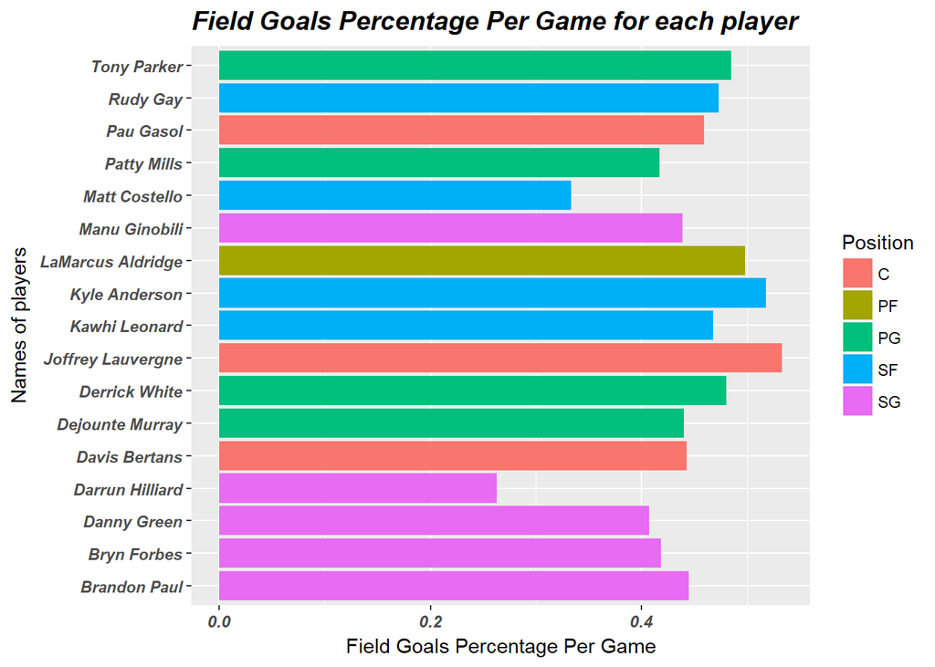

```r
library(ggplot2)
mytheme <- theme(plot.title = element_text(face = "bold.italic",size= 14, color = "black"), axis.text.x = element_text(size = 9, face ="bold.italic"), axis.text.y = element_text(face = "bold.italic"))
ggplot(data = Shooting_1, aes(x = Shooting_1$Name, y = Shooting_1$`FG%`, fill = Position), horis=TRUE)+geom_bar(stat = "identity")+labs(title = "Field Goals Percentage Per Game for each player", x="Names of players",y="Field Goals Percentage Per Game")+mytheme+coord_flip()
```